# Eye Tracking Quality Toolbox

Heidi Baumgartner

5/2/2017

> written by Heidi Baumgartner and Rachel Martino at the [Developmental Cognitive Neuroscience Lab](http://research.clps.brown.edu/dcnl/) at Brown University, directed by Dr. Dima Amso

[figure not shown]

# Overview

Some eye-tracking (ET) systems collect independent data streams from each eye (left and right), but analysis protocols often require the user to choose one eye or the other for analysis purposes. In optimal circumstances, it makes little difference which eye is used because these data streams are nearly identical. Sometimes, however, the data stream from one eye is significantly more stable or accurate than the stream from the other eye (*e.g.*, this situation occurs often when tracking very young participants with a between-eye distance that is at the lower limit of what the eye tracker can handle).

This toolbox is designed to quantify the **TRACKING RATIO** (percent of ET samples with non-zero gaze coordinates) and calibration **ACCURACY** (deviation of estimated point-of-regard from defined coordinates) by eye (R/L) for eye tracking data and to **RECOMMEND** which eye to use for subsequent analyses based on these metrics. The toolbox is designed to work with data generated by BeGaze (SensoMotoric Instruments), but should work as long as the variables/format specified in Using a non-SMI system are present.

# Instructions

Refer to the ET Quality Toolbox USER GUIDE for instructions on using the toolbox to generate quality metrics and eye recommendations.

# Set parameters

**These are the experiment-specific parameters that must be defined by the user.**  
*Once these parameters have been set, you should not have to edit code in other sections beyond tinkering with plot sizing.*

1. Update *datadir* to reflect correct path to data and *outputname* with desired name of summary output file
   - **IMPORTANT:** Make sure that the *only* .txt file(s) in the directory specified by *datadir* is raw gaze data in the format specified above, because the toolbox will attempt to load/append all .txt files in *datadir*. Any files not in this format will cause the toolbox to break.

```r
## path to data directory
datadir <- "/Users/heidibaumgartner/Documents/ETQuality_toolbox/ExampleData"

## file name for summary metrics
outputname <- "ETQuality_toolbox_output.csv"
```

2. **Set thresholds** for ‘meaningful’ differences (*i.e.*, discrepancies that are big enough to care about and therefore should be used for eye choice determination) for the following metrics:
   - **Tracking ratio** (*Threshold_TrackingDiff*): default difference threshold is 5% (i.e., only use tracking ratio for eye choice recommendation if TR for one eye is >5% better than TR for other eye)
   - **Validation accuracy** (*Threshold_AccuracyDiff*): default difference threshold is 25 pixels (i.e., only use validation deviation values for eye choice recommendation if deviation values for one eye are >25 pixels closer to validation-stimulus center than deviation values for other eye)

```r
## threshold for meaningful tracking ratio difference (%)
Threshold_TrackingDiff <- 5 # %

## threshold for meaningful deviation difference (pixels)
Threshold_AccuracyDiff <- 25  # pixels
```

3. Define stimuli to be used for validation purposes (*ValidationStim*), AOIs (*ValidataionAOI*), and stimulus coordinates (*ValidationX/Y*)
   - Make sure that these four lists all have the same number of items
   - If using the DCNL custom validation block, use default values

```r
## define names of stimuli used to measure validation accuracy
ValidationStim <- c('validation1.jpg',
                    'validation2.jpg',
                    'validation3.jpg',
                    'validation4.jpg')

## AOIs for corresponding items in 'ValidationStim'
ValidationAOI <- c('validation1',
                   'validation2',
                   'validation3',
                   'validation4')

## X coordinates for center of corresponding items in 'ValidationStim'
ValidationX <- c(480,
                 1440,
                 480,
                 1440)

## Y coordinates for center of corresponding items in 'ValidationStim'
ValidationY <- c(270,
                 270,
                 810,
                 810)
```

4. Define experimental stimuli (*ExperimentalStim*) that you want to INCLUDE in tracking ratio and distance calculations
   - To define non-experimental stimuli to EXCLUDE from these calculations instead, COMMENT OUT *ExperimentalStim* definition and use/edit *FillerStim* instead.
   - If you want to include all stimuli in tracking ratio/distance calculations, comment out *ExperimentalStim* and use *FillerStim <- c(‘nothing’)*

```r
## define stimulus names to be INCLUDED in tracking ratio/distance calculations
ExperimentalStim <- c('Pic1.jpg', 'Pic2.jpg', 'Pic3.jpg', 'Movie1.avi', 'Movie2.avi')

## define filler stimulus names to be EXCLUDED from tracking ratio/distance calculations
# FillerStim <- c('Validation.jpg', 'validation1.jpg', 'validation2.jpg', 'validation3.jpg', 'validation4.jpg', 'Fixation.png')

## to include ALL stimuli in tracking ratio/distance calculations, use this instead
# FillerStim <- c('nothing')
```

5. Choose if you want to save plots to individual files (*saveplotstofile*) and edit plot aesthetics (e.g., color, marker shape) (optional)

```r
## save plots as individual files?
saveplotstofile <- 1 # 0=no, 1=yes

## Aesthetics for plots (can change as desired)
marker_colors <- c('#007c92', '#e98300', '#8c1515','#8c1515')
marker_fills <- c('#007c92', NA, NA, NA) # NA for no fill
marker_shapes <- c(21,21,4,4) # 21=circle, 22=square, 23=diamond, 24=triangle, 25=invertedtriangle, 4=X
marker_size <- 2
marker_stroke <- 2
title_color <-  '#8c1515'
title_size <- 18 # font size of plot titles
axis_size <- 12 # font size of axis titles

## grayscale color options
# marker_colors <- c('gray', 'black', 'black', 'black')
# marker_fills <- c('gray', NA, NA, NA)
# title_color <- 'black'
```

# Load and organize data

[You shouldn’t need to change anything here unless you are using data generated outside of BeGaze and need to adjust for different variable names in data file(s).]

# Tracking ratio

Tracking Ratio is calculated by dividing the number of samples with non-0 gaze data (*TrackedSamples*) by total number of samples for the subset of stimuli defined above (either for stimuli defined in *ExperimentalStim* list or for all stimuli other than those defined in *FillerStim* list), then multiplied by 100 to convert to percentage.

$$TR = (\frac{TrackedSamples}{TotalSamples}) * 100$$

## Table 1: Tracking ratio values and eye comparisons

- *BetterTracking:* Eye with better tracking ratio (difference between eyes not necessarily above threshold!)
- *TrackingDiff:* Absolute difference of L and R tracking ratios

```
##    Subject BetterTracking TrackingDiff TrackingRatio_L TrackingRatio_R
## 1:     P01             NA            0             100             100
## 2:     P02              L           45              99              54
## 3:     P03              R           25              63              88
## 4:     P04              L            2              52              50
## 5:     P05             NA            0              90              90
##    TotalSamples NSamples_L NSamples_R
## 1:         2322       2322       2313
## 2:         2500       2480       1338
## 3:         2653       1659       2341
## 4:         5604       2912       2828
## 5:         3156       2846       2842
```

## Figure 1a: Tracking ratio

This plot provides a quick visualization of tracking ratio by eye for each subject.

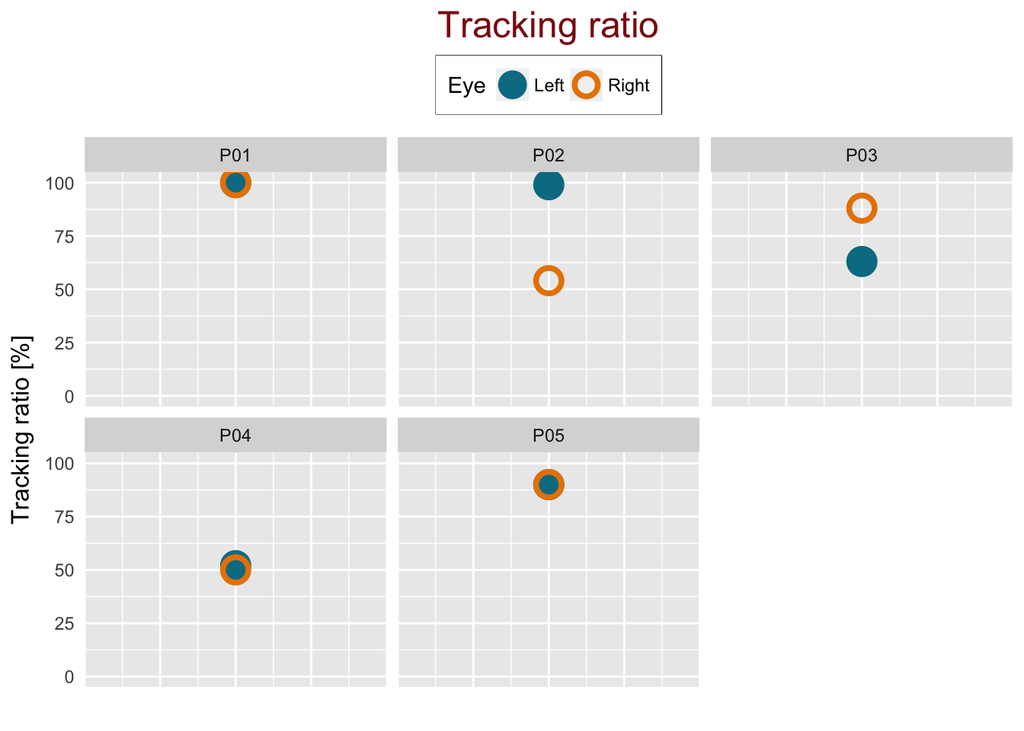

## Figure 1b: Tracking ratio, by stimulus (all trials)

This plot provides a visualization of tracking ratio by stimulus. This allows you to quickly see if tracking ratio differs or is consistent across stimuli. Each circle represents a single presentation of the stimulus. Data points are jittered so that if stimuli are presented more than once, you will be able to see the tracking ratio during each presentation.

*NOTE: If stimuli do not repeat (1 trial per stimulus), this figure will be redundant with Figure 1c.*

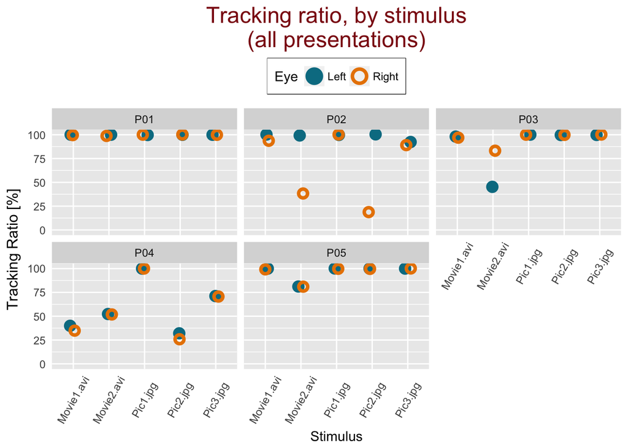

## Figure 1c: Tracking ratio, by stimulus (stimulus averages)

This plot provides a visualization of tracking ratio by stimulus. If stimuli are presented more than once, the data point represents the tracking ratio (by eye) averaged across all presentations of that stimulus.

*NOTE: If stimuli do not repeat (1 trial per stimulus), this figure will be redundant with Figure 1b.*

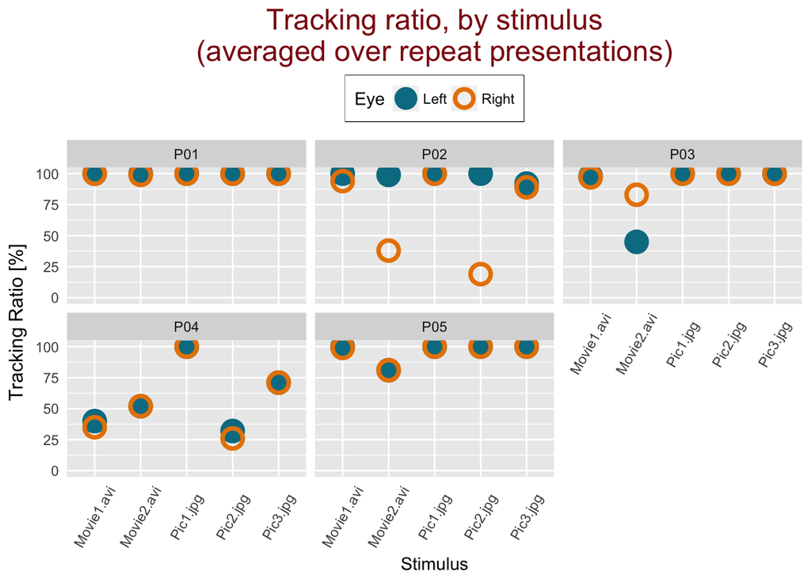

## Figure 1d: Tracking ratio, by trial

This plot provides a visualization of tracking ratio by trial. This allows you to quickly see if a subject’s tracking ratio is consistent or changes over time.

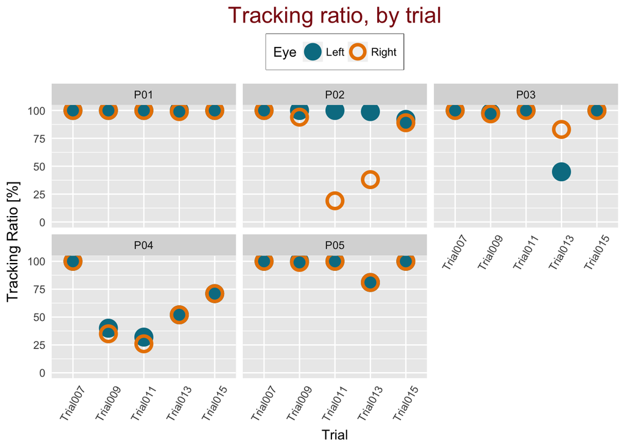

# Calibration accuracy

Deviation statistics are calculated using the longest fixation to the validation stimulus on each validation trial (based on the assumption that the longest fixation that falls within the validation AOI on each trial most likely reflects looking to the validation stimulus). The average euclidean distance (deviation) from each point-of-regard (POR) within the longest fixation to the validation stimulus is calculated for each trial. Deviation values are then averaged over all validation trials to generate an average deviation value.

$$\begin{aligned}
Deviation_{sample} &= \sqrt{(STIM_{x}-POR_{x})^2+(STIM_{y}-POR_{y})^2} \\
Deviation_{fixation} &= mean(Deviation_{samples}) \\
Deviation_{average} &= mean(Deviation_{LongestFixations})
\end{aligned}$$

## Table 2: Deviation values

- *BetterAccuracy:* Eye with better (*i.e.*, smaller) deviation value (not necessarily above threshold!)
- *AccuracyDiff:* Absolute difference of L and R deviation values
- *stdev_L/R:* Average standard deviation of deviation values within each fixation (higher values indicate less stable fixations)
- *Duration_L/R:* Average fixation duration of fixations used to calculate deviations

```
##    Subject BetterAccuracy AccuracyDiff Deviation_L   stdev_L Duration_L
## 1:     P01              L    20.944346    25.02673 12.873421   1716.050
## 2:     P02              L     6.874652    43.72860  5.828800   1620.275
## 3:     P03              L     7.902798    71.87286 12.531135   1591.075
## 4:     P04              L    12.543479    23.42790  5.403864   2188.067
## 5:     P05              L    11.713289   106.00528  7.858005   2165.800
##    Deviation_R   stdev_R Duration_R
## 1:    45.97108  8.626094    1607.75
## 2:    50.60325 10.235618    1536.95
## 3:    79.77566  9.758520    1666.05
## 4:    35.97138  8.848672    2749.10
## 5:   117.71856 10.834453    1932.50
```

## Figure 2a: Deviation values

This plot shows average deviation values (i.e., average distance of estimated POR from center of validation stimulus) by eye for each subject. Smaller deviation values indicate a better calibration/more accurate tracking.

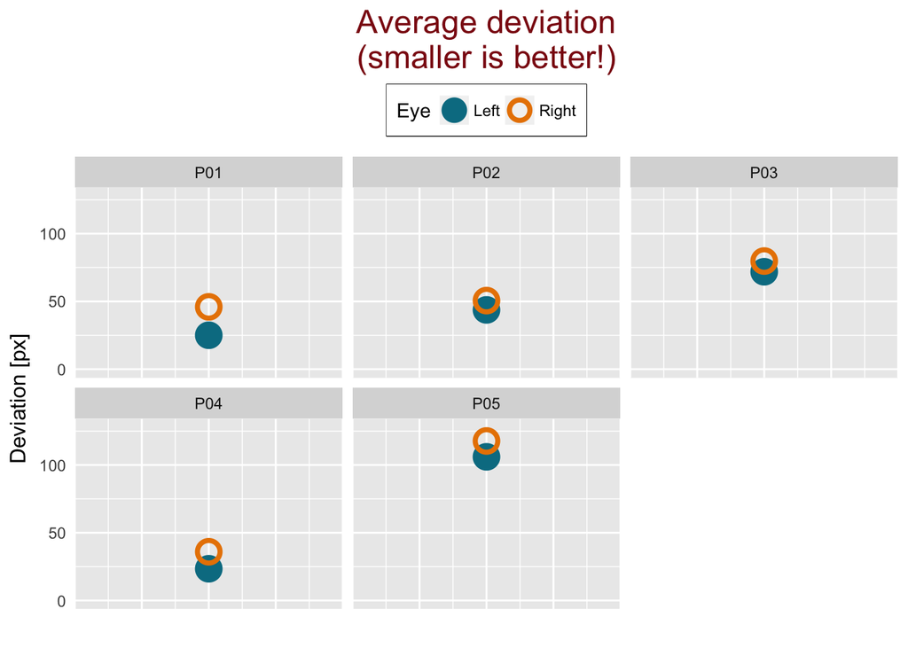

## Figure 2b: Deviation values, by validation stimulus

This plot shows deviation values for each validation stimulus. This allows you to see at a glance if high deviations are due to a generally poor calibration (consistently high values across stimuli) or outlier value(s). It also allows you to see if any participants are missing data for one or more validation stimuli (missing data will result in a displayed warning before the plot).

```
## Warning: Removed 1 rows containing missing values (geom_point).
```

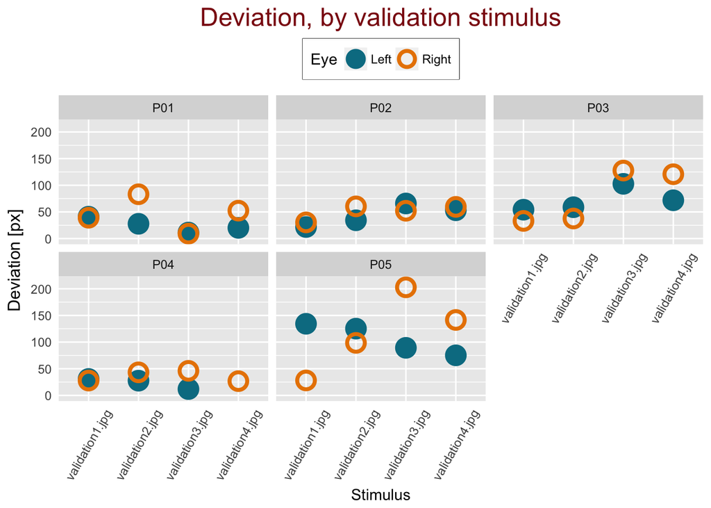

```
## Warning: Removed 1 rows containing missing values (geom_point).
```

## Figure 2c: Deviation values, validation trial

This plot shows deviation values for each validation trial in the order in which they were presented. This allows you to see at a glance if deviations are consistent or change (drift) over time.

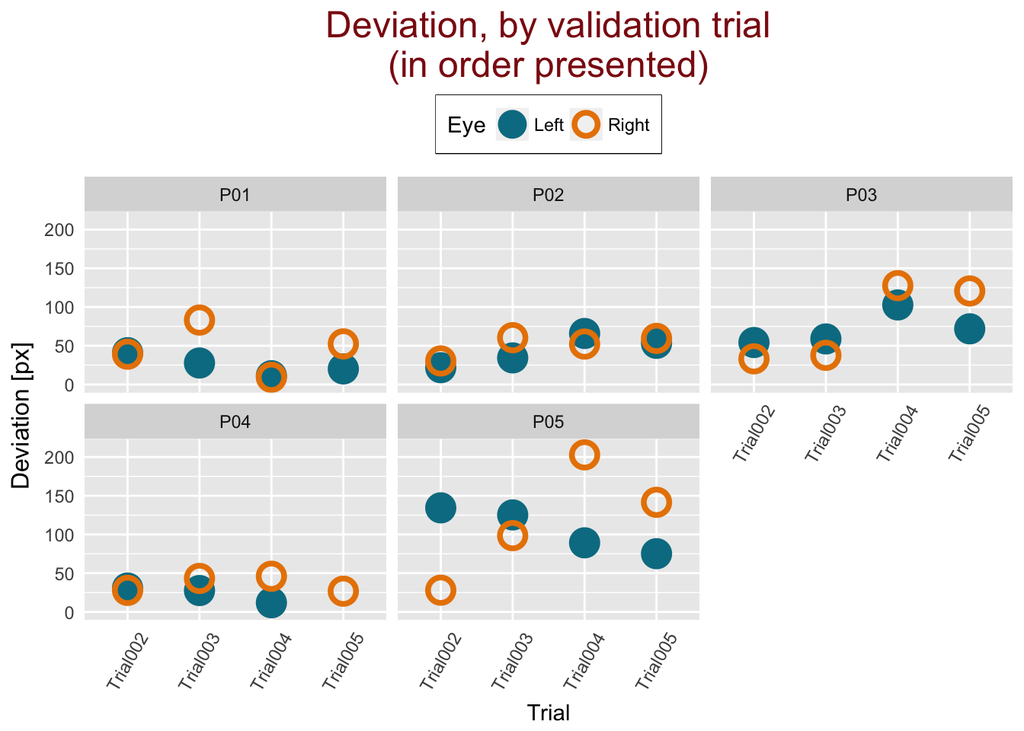

# Distance from screen

Participants’ average distance from the screen (using eye position Z value) is calculated for each eye during samples in which non-zero gaze data was collected (exluding non-experimental stimuli). This is probably not interesting/useful for deterimining which eye to use for analyses, but you might want to use the distance measure from the chosen eye when calculating a group average.

## Table 3: Distance from screen (during experimental trials)

*Distance is in mm*

```
##    Subject ScreenDistance_R ScreenDistance_L
## 1:     P01         644.6132         647.5126
## 2:     P02         632.3205         627.6549
## 3:     P03         605.0091         597.7266
## 4:     P04         591.3879         583.8653
## 5:     P05         542.5811         532.8221
```

## Figure 3: Distance from screen

This plot shows each subject’s average distance from the screen across all experimental trials.

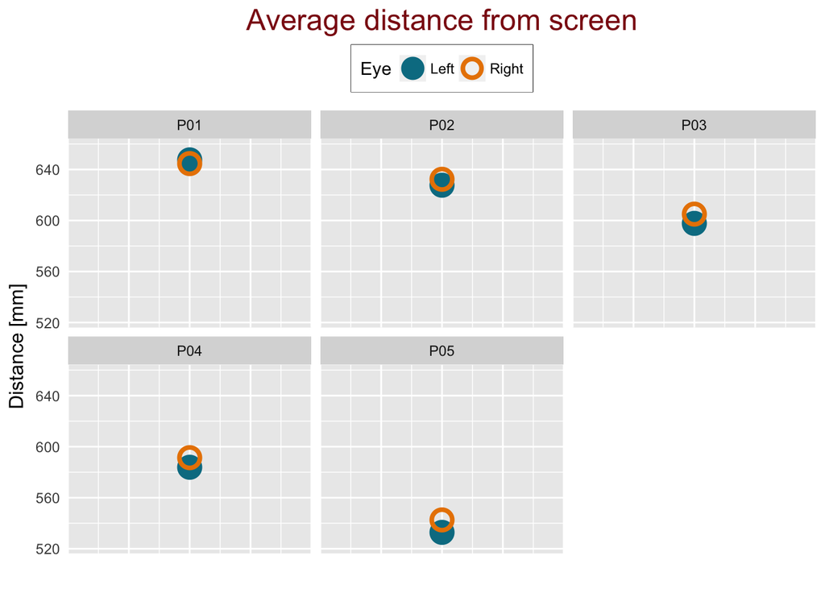

# Eye recommendation by subject

The toolbox now uses the decision parameters outlined in the Overview section to recommend which eye provides ‘better’ data for each participant. The decision tree can be adjusted based on the priorities of the experiment (*e.g.*, if tracking accuracy is less important than data quantity).

A flag of **UNDETERMINED: missing data** indicates that there were no fixations within the specified AOIs for the stimuli listed in *ValidationStim*, so the toolbox cannot make a recommendation based on tracking accuracy information. A flag of **UNDETERMINED: conflict** indicates that one eye has a better tracking ratio and the other eye has better accuracy, so the user should examine the data and make a determination of which eye to use.

## Figure 4: Eye recommendations

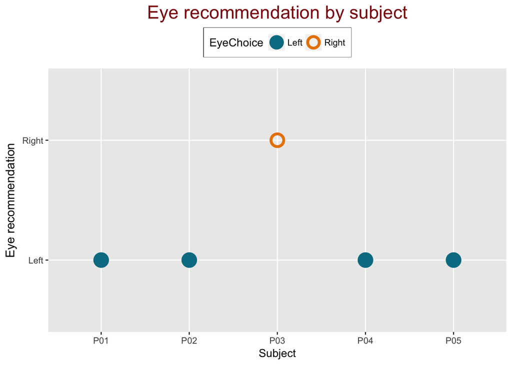

## Table 4: Summary metrics/statistics table, with eye recommendations

This table is written to a .csv file and saved in the data directory.

**Variable definitions:**

- *EyeChoice:* This is the eye that has been determined to provide higher quality data and should thus be used for all subsequent analyses
- *Match_TrackAccuracy:* This variable indicates if both tracking ratio and deviation metrics were better for the same eye (1) or if one eye had a better tracking ratio and the other eye had a lower validation deviation (0)
- *BetterTracking:* Eye with higher tracking ratio
- *TrackingDiffAboveThresh:* Indicates if difference in tracking ratio between eyes exceeds threshold value
- *BetterAccuracy:* Eye with lower deviation value
- *AccuracyDiffAboveThresh:* Indicates if difference in deviation value between eyes exceeds threshold value
- *TrackingDiff, TrackingRatio_L/R:* Tracking ratio values for each eye and difference between values
- *TotalSamples:* Total number of eye tracking samples (experimental stimuli only) in data file (denominator for tracking ratio)
- *NSamples_L/R:* Number of samples with non-zero gaze data (experimental stimuli only) for each eye (numerator for tracking ratio)
- *AccuracyDiff, stdev_L/R, Duration_L/R, Deviation_L/R:* Difference between L/R deviation values, SD for deviation values (across stimuli), average duration of fixations used to calculate deviations
- *ScreenDistance_L/R:* Average distance from screen [mm] for each eye (during experimental stimuli)

```
##    Subject EyeChoice Match_TrackAccuracy BetterTracking
## 1:     P01      Left                   1              L
## 2:     P02      Left                   1              L
## 3:     P03     Right                   0              R
## 4:     P04      Left                   1              L
## 5:     P05      Left                   1              L
##    TrackingDiffAboveThresh BetterAccuracy AccuracyDiffAboveThresh
## 1:                       0              L                       0
## 2:                       1              L                       0
## 3:                       1              L                       0
## 4:                       0              L                       0
## 5:                       0              L                       0
##    TrackingDiff TrackingRatio_L TrackingRatio_R TotalSamples NSamples_L
## 1:            0             100             100         2322       2322
## 2:           45              99              54         2500       2480
## 3:           25              63              88         2653       1659
## 4:            2              52              50         5604       2912
## 5:            0              90              90         3156       2846
##    NSamples_R AccuracyDiff Deviation_L   stdev_L Duration_L Deviation_R
## 1:       2313    20.944346    25.02673 12.873421   1716.050    45.97108
## 2:       1338     6.874652    43.72860  5.828800   1620.275    50.60325
## 3:       2341     7.902798    71.87286 12.531135   1591.075    79.77566
## 4:       2828    12.543479    23.42790  5.403864   2188.067    35.97138
## 5:       2842    11.713289   106.00528  7.858005   2165.800   117.71856
##      stdev_R Duration_R ScreenDistance_R ScreenDistance_L
## 1:  8.626094    1607.75         644.6132         647.5126
## 2: 10.235618    1536.95         632.3205         627.6549
## 3:  9.758520    1666.05         605.0091         597.7266
## 4:  8.848672    2749.10         591.3879         583.8653
## 5: 10.834453    1932.50         542.5811         532.8221
```

# Appendix: Distributions of L/R differences relative to thresholds

This is meant to provide a visualization of the distribution of differences between eyes for quantity and accuracy metrics to help the user select threshold values for what constitutes a meaningful difference (and thus should be taken into account when choosing which eye’s data to use for analyses).

## Histogram: Tracking ratio L/R difference

Current threshold for a meaningful tracking ratio difference is 5%. Currently, 2 of 5 participants have a tracking ratio difference above this threshold.

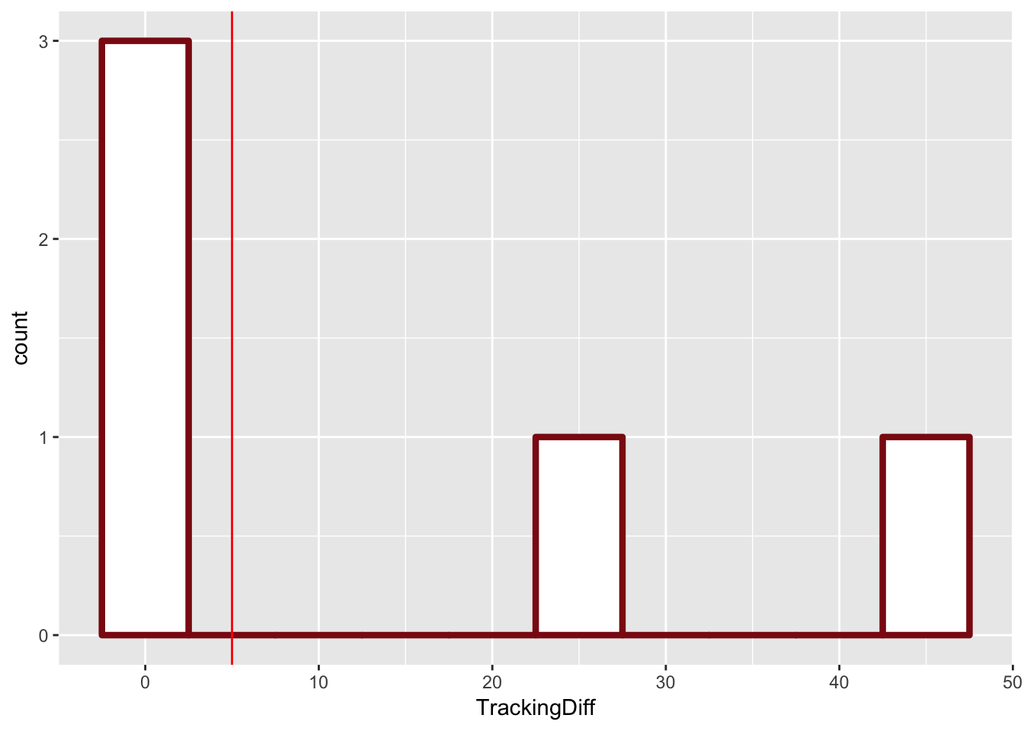

## Histogram: Deviation value (accuracy) L/R difference

Current threshold for a meaningful deviation value difference is 25 pixels. Currently, 0 of 5 participants have a deviation value difference above this threshold.

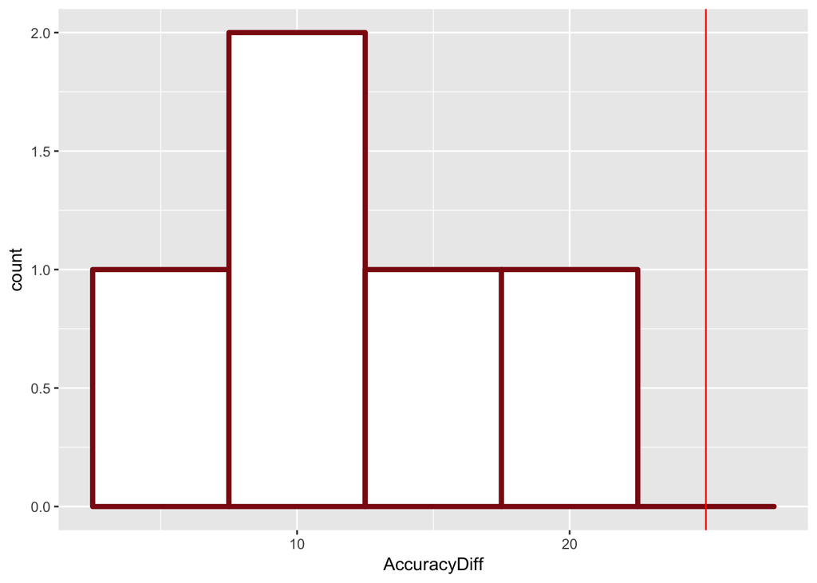

# Contact

Contact Heidi Baumgartner (heidibaum@gmail.com) with questions or with feature requests.

Special thanks to Kristen Tummeltshammer, Andrew Lynn, and other members of the DCN Lab at Brown University for help with testing and feature suggestions.